# Prediction Assignment

The objective of this Prediction Assignment is to predict type of exercise by other key variables taken by accelerometers in different body parts.

This key measures, will help us to predict what kind of exercise you are doing.

In this Assignment I´m using the libraries:

scatterplot3d, caret, randomForest, AppliedPredictiveModeling

The first step is to obtain our data,

```r
ORIGINAL_DATA <- read.csv("pml-training.CSV", stringsAsFactors = FALSE)
```

Then we are constructing 2 data sets, in order to use the first one as a training data set, and the other as a testing data set.

```r
adData = data.frame(ORIGINAL_DATA)
trainsplit = createDataPartition(ORIGINAL_DATA$classe,p=0.5,list=FALSE)
training = adData[trainsplit,]
testing = adData[-trainsplit,]
```

In order to determine the relevant variables, first we need to clean our data set. With the function str, we can list our variables and exclude variables with NA, or without values or data. This help us to reduce the amount of variables.

```r
str(training, list.len=ncol(training))
```

```
## 'data.frame':    9812 obs. of  160 variables:
##  $ X                       : int  1 4 8 10 13 14 15 16 27 29 ...
##  $ user_name               : chr  "carlitos" "carlitos" "carlitos" "carlitos" ...
##  $ raw_timestamp_part_1    : int  1323084231 1323084232 1323084232 1323084232 1323084232 1323084232 1323084232 1323084232 1323084233 1323084233 ...
##  $ raw_timestamp_part_2    : int  788290 120339 440390 484434 560359 576390 604281 644302 72305 136333 ...
##  $ cvtd_timestamp          : chr  "05/12/2011 11:23" "05/12/2011 11:23" "05/12/2011 11:23" "05/12/2011 11:23" ...
##  $ new_window              : chr  "no" "no" "no" "no" ...
##  $ num_window              : int  11 12 12 12 12 12 12 12 13 13 ...
##  $ roll_belt               : num  1.41 1.48 1.42 1.45 1.42 1.42 1.45 1.48 1.54 1.52 ...
##  $ pitch_belt              : num  8.07 8.05 8.13 8.17 8.2 8.21 8.2 8.15 8.11 8.16 ...
##  $ yaw_belt                : num  -94.4 -94.4 -94.4 -94.4 -94.4 -94.4 -94.4 -94.4 -94.4 -94.4 ...
##  $ total_accel_belt        : int  3 3 3 3 3 3 3 3 3 3 ...
##  $ kurtosis_roll_belt      : chr  "" "" "" "" ...
##  $ kurtosis_picth_belt     : chr  "" "" "" "" ...
##  $ kurtosis_yaw_belt       : chr  "" "" "" "" ...
```

[output cut: 146 more lines]

The next step that I use in this research is to make 3D plots, in order to understand the variables that have higher impact in prediction.

The library scatterplot3d, help us to construct 3d plots. The first step is to create a variable that assign different colors by Classe.

```r
training$pcolor[training$classe=="A"] <- "red"
training$pcolor[training$classe=="B"] <- "blue"
training$pcolor[training$classe=="C"] <- "darkgreen"
training$pcolor[training$classe=="D"] <- "yellow"
training$pcolor[training$classe=="E"] <- "black"
```

In the next plot, we can see that variables:

raw_timestamp_part_1, pitch_forearm, roll_belt

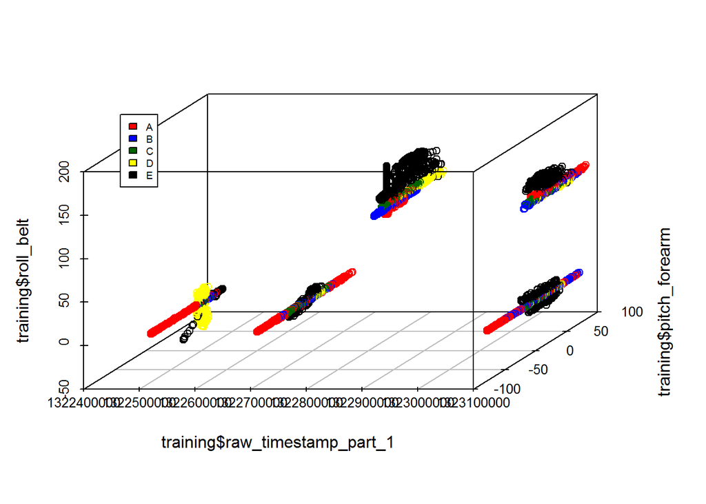

```r
f <- scatterplot3d(training$raw_timestamp_part_1, training$pitch_forearm, training$roll_belt, color = training$pcolor)
legend("topleft", inset=0.1, cex=.6,    c("A", "B", "C", "D", "E"), fill=c("red", "blue", "darkgreen", "yellow", "black"))
```

In the second plot, we can see that num_window, magnet_dumbbell_z and yaw_belt

are relevant too for the research, because we can observe how the data is fragmented by classe category.

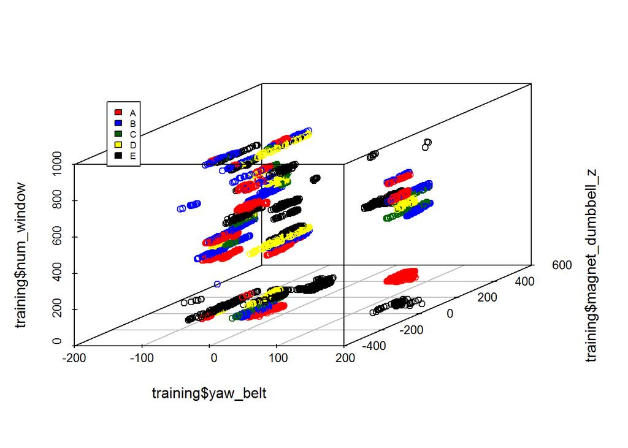

```r
g <- scatterplot3d(training$yaw_belt, training$magnet_dumbbell_z, training$num_window, color = training$pcolor)
legend("topleft", inset=0.1, cex=.6,    c("A", "B", "C", "D", "E"), fill=c("red", "blue", "darkgreen", "yellow", "black"))
```

With this kind of plots I choose the variables of my final model:

raw_timestamp_part_1, classe, num_window + roll_belt, pitch_forearm, yaw_belt, magnet_dumbbell_z, accel_dumbbell_x, yaw_arm

The method chosen to construct prediction is Random Forest

```r
modFit <- train(as.factor(classe) ~ raw_timestamp_part_1 + classe + num_window + roll_belt + pitch_forearm + yaw_belt + magnet_dumbbell_z + accel_dumbbell_x + yaw_arm,
                method = "rf", data = training[c("raw_timestamp_part_1", "classe", "num_window", "roll_belt", "pitch_forearm", "yaw_belt", "magnet_dumbbell_z", "accel_dumbbell_x", "yaw_arm")])
```

```r
modFit$finalModel
```

```
##
## Call:
##  randomForest(x = x, y = y, mtry = param$mtry)
##                Type of random forest: classification
##                      Number of trees: 500
## No. of variables tried at each split: 2
##
##         OOB estimate of  error rate: 0%
## Confusion matrix:
##      A    B    C    D    E class.error
## A 2790    0    0    0    0           0
## B    0 1899    0    0    0           0
## C    0    0 1711    0    0           0
## D    0    0    0 1608    0           0
## E    0    0    0    0 1804           0
```

```r
predictions <- predict(modFit,newdata= testing)
```

```r
confusionMatrix(predictions,testing$classe)
```

```
## Confusion Matrix and Statistics
##
##           Reference
## Prediction    A    B    C    D    E
##          A 2790    0    0    0    0
##          B    0 1898    0    0    0
##          C    0    0 1711    0    0
##          D    0    0    0 1608    0
##          E    0    0    0    0 1803
##
## Overall Statistics
##
##                Accuracy : 1
##                  95% CI : (0.9996, 1)
##     No Information Rate : 0.2844
##     P-Value [Acc > NIR] : < 2.2e-16
##
##                   Kappa : 1
##  Mcnemar's Test P-Value : NA
##
## Statistics by Class:
##
##                      Class: A Class: B Class: C Class: D Class: E
## Sensitivity            1.0000   1.0000   1.0000   1.0000   1.0000
## Specificity            1.0000   1.0000   1.0000   1.0000   1.0000
## Pos Pred Value         1.0000   1.0000   1.0000   1.0000   1.0000
## Neg Pred Value         1.0000   1.0000   1.0000   1.0000   1.0000
## Prevalence             0.2844   0.1935   0.1744   0.1639   0.1838
## Detection Rate         0.2844   0.1935   0.1744   0.1639   0.1838
## Detection Prevalence   0.2844   0.1935   0.1744   0.1639   0.1838
## Balanced Accuracy      1.0000   1.0000   1.0000   1.0000   1.0000
```

And the last step is to analyze the variable importance,

```r
varImp(modFit)
```

```
## rf variable importance
##
##                      Overall
## classeB              100.000
## classeC               92.239
## classeD               84.550
## classeE               81.147
## raw_timestamp_part_1  20.730
## roll_belt             19.942
## pitch_forearm         16.287
## num_window            14.088
## magnet_dumbbell_z      9.849
## yaw_belt               5.304
## accel_dumbbell_x       3.029
## yaw_arm                0.000
```